# Geometric Means Trial

## How does the number of measurements used in calculating the geometric mean affect the effect sizes in a regression model?

- gm1 = Hl, Fl
- gm2 = Hl , Hsw , Fl , Fsw
- gm3 = Hl , Ul , Tl , Fl
- gm4 = Hl , Ul , Tl , Fl , Hsw , Fsw , Tmw
- gm5 = Hl , Ul , Tl , Fl , Hsw , Fsw , Fdw , Fsw , Sl , Sh , Hdw
- gm6 = Hl , Ul , Tl , Fl , Hsw , Fsw , Fdw , Fsw , Sl , Sh , Hdwm, Mcl, Ppl

To determine how estimates change, we will want to run the same model but alternate the gm measurement. log(Humerus length) seems to be a pretty good correlate of climbing, when conditioned on body size, so lets go with that one.

I’m going to ignore intraspecific variation & phylogenetic variation for now.

Here are the models

```r
# Geometric Mean models
mgm1 <- brm(Loc_bin ~ Hl + gm1,
           family = bernoulli(),
           data = dat, refresh = 0, seed = 131)
mgm2 <- update(mgm1, Loc_bin ~ Hl + gm2, newdata = dat, refresh = 0, seed = 131)
mgm3 <- update(mgm1, Loc_bin ~ Hl + gm3, newdata = dat, refresh = 0, seed = 131)
mgm4 <- update(mgm1, Loc_bin ~ Hl + gm4, newdata = dat, refresh = 0, seed = 131)
mgm5 <- update(mgm1, Loc_bin ~ Hl + gm5, newdata = dat, refresh = 0, seed = 131)
mgm6 <- update(mgm1, Loc_bin ~ Hl + gm6, newdata = dat, refresh = 0, seed = 131)
# log mass model
lm <- update(mgm1, Loc_bin ~ Hl + log_Mass, newdata = dat, refresh = 0, seed = 131)
# no mass model for comparison
nom <- update(mgm1, Loc_bin ~ Hl , newdata = dat, refresh = 0, seed = 131)
```

[figure not shown]

The results are strongly supported with model comparison

```r
loo(mgm1, mgm2,mgm3, mgm4, mgm5, mgm6, lm)[[2]]
```

```
##      elpd_diff se_diff
## lm     0.0       0.0
## mgm5 -21.6      10.3
## mgm4 -23.3      10.5
## mgm6 -23.3      10.4
## mgm2 -27.2      10.3
## mgm3 -31.7      10.8
## mgm1 -35.1      10.7
```

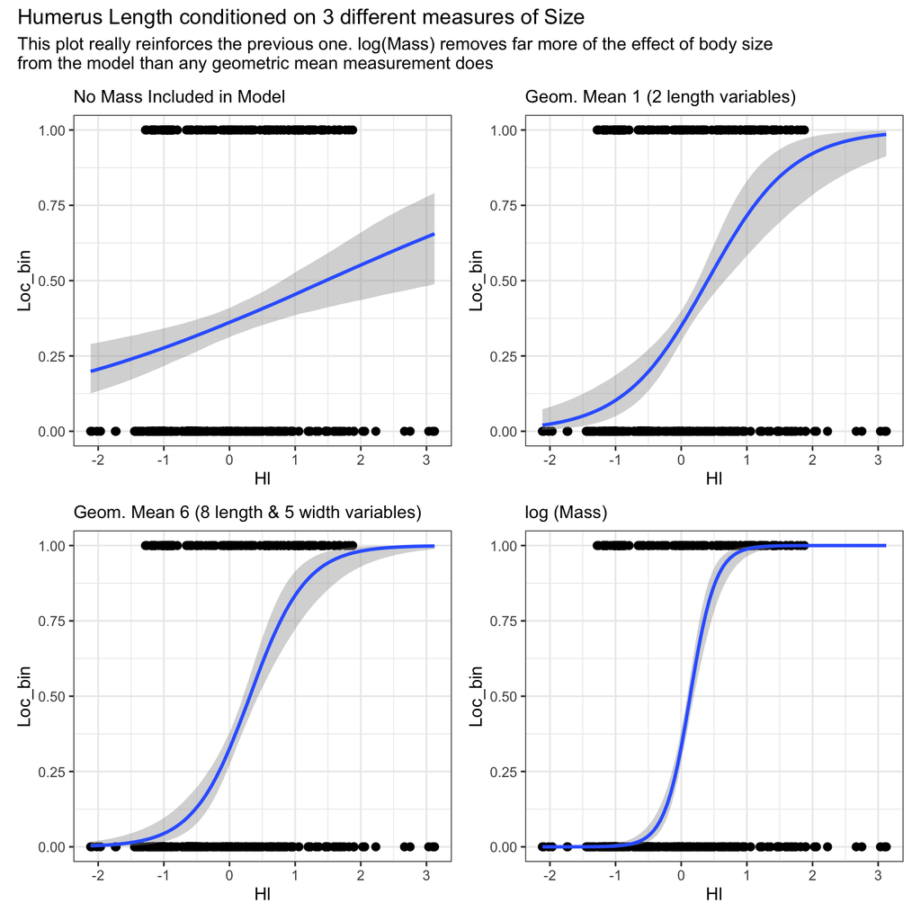

Lets fit a couple of models with other variables for fun

```r
# Geometric Mean models
mgm1.2 <- update(mgm1, Loc_bin ~ Ppl + gm1, newdata = dat, refresh = 0, seed = 131)
mgm2.2 <- update(mgm1, Loc_bin ~ Ppl + gm2, newdata = dat, refresh = 0, seed = 131)
mgm3.2 <- update(mgm1, Loc_bin ~ Ppl + gm3, newdata = dat, refresh = 0, seed = 131)
mgm4.2 <- update(mgm1, Loc_bin ~ Ppl + gm4, newdata = dat, refresh = 0, seed = 131)
mgm5.2 <- update(mgm1, Loc_bin ~ Ppl + gm5, newdata = dat, refresh = 0, seed = 131)
mgm6.2 <- update(mgm1, Loc_bin ~ Ppl + gm6, newdata = dat, refresh = 0, seed = 131)
# log mass model
lm.2 <- update(mgm1, Loc_bin ~ Ppl + log_Mass, newdata = dat, refresh = 0, seed = 131)
# no mass model for comparison
nom.2 <- update(mgm1, Loc_bin ~ Ppl , newdata = dat, refresh = 0, seed = 131)
```

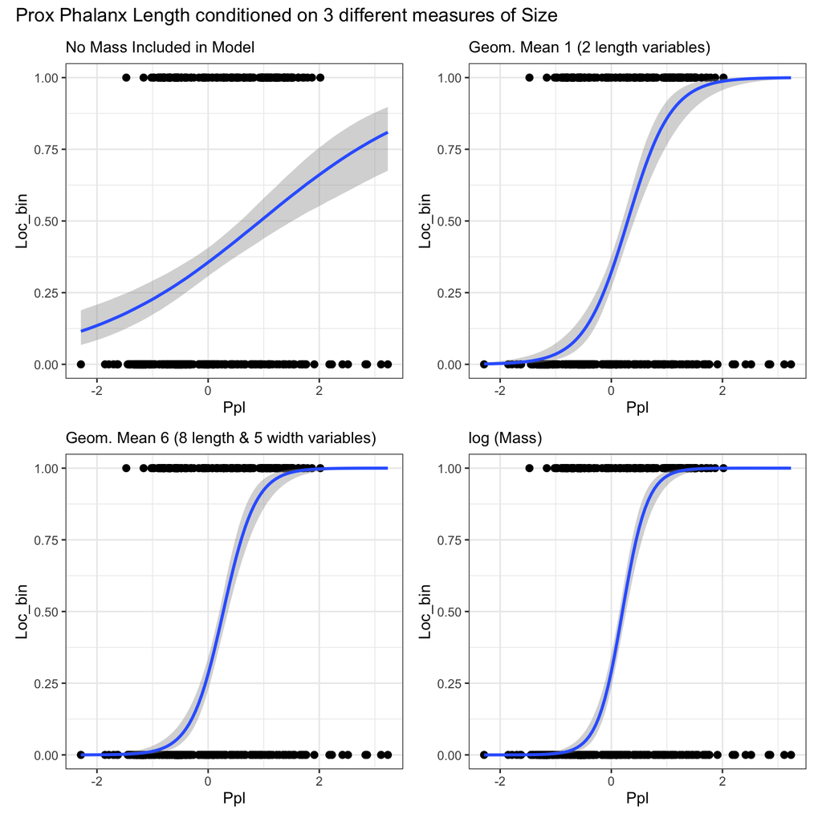

And Prox Plalanx Length does a better job predicting locomotion than humerus across the board!

```r
loo( mgm4, mgm4.2, mgm6, mgm6.2, lm, lm.2)[[2]]
```

```
##        elpd_diff se_diff
## lm.2     0.0       0.0
## mgm6.2 -13.4       9.7
## mgm4.2 -18.0       9.6
## lm     -25.5       9.1
## mgm4   -48.7      11.8
## mgm6   -48.7      12.0
```